# AIRBNB - PARIS

Saifuddin Mohammad

5/12/2020

# Analysis of data based on statistics for AirBnB - Paris

We load the given data into R studio:

```r
data <- load("C:\\Users\\verce\\Downloads\\AirBnB.Rdata")

head(data)
```

```
## [1] "L" "R"
```

```r
#View(data)
```

There is a lot of data so we will be looking at the row names to get an idea of what’s in there.

It is also helpful to know the dimensions of this data:

```r
typeof(L)
```

```
## [1] "list"
```

```r
typeof(R)
```

```
## [1] "list"
```

```r
dim(L)
```

```
## [1] 52725    95
```

```r
dim(R)
```

```
## [1] 663599      2
```

```r
head(colnames(L))
```

```
## [1] "id"           "listing_url"  "scrape_id"    "last_scraped" "name"
## [6] "summary"
```

```r
colnames(R)
```

```
## [1] "listing_id" "date"
```

The data contains several attributes for a housing company - AirBnB.

In the first instance the data may look organized but looking closer we realise that we have to clean this data.

```r
class(L)
```

```
## [1] "data.frame"
```

```r
class(R)
```

```
## [1] "data.frame"
```

```r
knitr::kable(head(L), caption = "Table with Kable")
```

Table with Kable

| id | listing_url | scrape_id | last_scraped | name | summary | space | description | experiences_offered | neighborhood_overview | notes | transit | access | interaction | house_rules | thumbnail_url | medium_url | picture_url | xl_picture_url | host_id | host_url | host_name | host_since | host_location | host_about | host_response_time | host_response_rate | host_acceptance_rate | host_is_superhost | host_thumbnail_url | … |
| --- | --- | --- | --- | --- | --- | --- | --- | --- | --- | --- | --- | --- | --- | --- | --- | --- | --- | --- | --- | --- | --- | --- | --- | --- | --- | --- | --- | --- | --- | --- |
| 4867396 | https://www.airbnb.com/rooms/4867396 | 2.01607e+13 | 2016-07-03 | Appartement 60m2 Rue Legendre 75017 | Au 2ème étage d’un bel immeuble joli 2 pièces meublé comprenant: une grande pièce Ã vivre lumineuse, une chambre, une cuisine, salle de douche et WC séparé. Appartement très calme et lumineux.… |  | Au 2ème étage d’un bel immeuble joli 2 pièces meublé comprenant: une grande pièce Ã vivre lumineuse, une chambre, une cuisine, salle de douche et WC séparé. Appartement très calme et lumineux.… | none |  |  |  |  |  |  |  |  | https://a1.muscache.com/im/pictures/61090424/02c8a8bb_original.jpg?aki_policy=large |  | 9703910 | https://www.airbnb.com/users/show/9703910 | Matthieu | 2013-10-29 | Nantes, Pays de la Loire, France |  | N/A | N/A | N/A | f | https://a0.muscache.com/im/users/9703910/profile_pic/1383073563/original.jpg?aki_policy=profile_small | … |
| 7704653 | https://www.airbnb.com/rooms/7704653 | 2.01607e+13 | 2016-07-04 | Appart au pied de l’arc de triomphe | Nous proposons cette appartement situé en plein coeur de Paris, au pied de l’arc de triomphe. Commerçants, métro, cinéma, vous trouverez Ã proximité tout ce qu’il faut pour passer quelques jours … | L’appartement est composé de : - une grande chambre (environ 15m2) avec un lit simple et d’un matelas d’appoint - une salle de bain avec douche, lave linge/sèche linge - un autre chambre (environ 10… | Nous proposons cette appartement situé en plein coeur de Paris, au pied de l’arc de triomphe. Commerçants, métro, cinéma, vous trouverez Ã proximité tout ce qu’il faut pour passer quelques jours … | none |  |  |  |  |  |  | https://a1.muscache.com/im/pictures/97911969/ef37b496_original.jpg?aki_policy=small | https://a1.muscache.com/im/pictures/97911969/ef37b496_original.jpg?aki_policy=medium | https://a1.muscache.com/im/pictures/97911969/ef37b496_original.jpg?aki_policy=large | https://a1.muscache.com/im/pictures/97911969/ef37b496_original.jpg?aki_policy=x_large | 35777602 | https://www.airbnb.com/users/show/35777602 | Claire | 2015-06-14 | Paris, Île-de-France, France |  | N/A | N/A | N/A | f | https://a1.muscache.com/im/users/35777602/profile_pic/1438688930/original.jpg?aki_policy=profile_small | … |
| 2725029 | https://www.airbnb.com/rooms/2725029 | 2.01607e+13 | 2016-07-04 | Nice appartment in Batignolles | Located in the very charming Batignolles, this cozy and bright two-room appartment will perfectly suit your stay in Paris. |  | Located in the very charming Batignolles, this cozy and bright two-room appartment will perfectly suit your stay in Paris. | none |  |  |  |  |  |  |  |  | https://a1.muscache.com/im/pictures/96821426/ea9864f1_original.jpg?aki_policy=large |  | 13945253 | https://www.airbnb.com/users/show/13945253 | Vincent | 2014-04-06 | Paris, Île-de-France, France |  | within an hour | 100% | N/A | f | https://a0.muscache.com/im/users/13945253/profile_pic/1396781528/original.jpg?aki_policy=profile_small | … |
| 9337509 | https://www.airbnb.com/rooms/9337509 | 2.01607e+13 | 2016-07-03 | Charming flat near Batignolles | Welcome to my apartment ! This a quiet and cosy flat with 2 room (25 sqm2) fully furnished closed to trendy Batignolles area in the heart of the 17th district. (Near Montmartre foothill / Place de Cli… |  | Welcome to my apartment ! This a quiet and cosy flat with 2 room (25 sqm2) fully furnished closed to trendy Batignolles area in the heart of the 17th district. (Near Montmartre foothill / Place de Cli… | none |  |  |  |  |  |  |  |  | https://a2.muscache.com/im/pictures/5fa65f2d-b159-4fb5-986a-bd36cb92d2bc.jpg?aki_policy=large |  | 5107123 | https://www.airbnb.com/users/show/5107123 | Julie | 2013-02-16 | Paris, Île-de-France, France | Nous sommes un jeune couple vivant Ã Paris. Nous aimons beaucoup voyager | within a day | 50% | N/A | f | https://a1.muscache.com/im/users/5107123/profile_pic/1425849895/original.jpg?aki_policy=profile_small | … |
| 12928158 | https://www.airbnb.com/rooms/12928158 | 2.01607e+13 | 2016-07-04 | Spacious bedroom near the centre of Paris | Spacious, quiet and bright room, ideal to explore and enjoy |  | Spacious, quiet and bright room, ideal to explore and enjoy | none |  |  |  |  |  |  | https://a2.muscache.com/im/pictures/df47511b-0e86-4dcb-9887-569489b16020.jpg?aki_policy=small | https://a2.muscache.com/im/pictures/df47511b-0e86-4dcb-9887-569489b16020.jpg?aki_policy=medium | https://a2.muscache.com/im/pictures/df47511b-0e86-4dcb-9887-569489b16020.jpg?aki_policy=large | https://a2.muscache.com/im/pictures/df47511b-0e86-4dcb-9887-569489b16020.jpg?aki_policy=x_large | 51195601 | https://www.airbnb.com/users/show/51195601 | Daniele | 2015-12-13 | Prato, Toscana, Italy |  | within an hour | 100% | 60% | f | https://a2.muscache.com/im/pictures/e984ba68-7571-46d9-99dc-735ec6e5c9d6.jpg?aki_policy=profile_small | … |
| 5589471 | https://www.airbnb.com/rooms/5589471 | 2.01607e+13 | 2016-07-04 | Rare, Maison individuelle 200m2 | Maison individuelle, 200 m2 habitable,rénovée en 2013. Quartier résidentiel, nombreux commerces, restaurants. Maison familiale, pouvant accueillir 5 adultes et un enfant (1 lit en hauteur). |  | Maison individuelle, 200 m2 habitable,rénovée en 2013. Quartier résidentiel, nombreux commerces, restaurants. Maison familiale, pouvant accueillir 5 adultes et un enfant (1 lit en hauteur). | none |  |  |  |  |  |  |  |  | https://a2.muscache.com/im/pictures/69589240/79d976c4_original.jpg?aki_policy=large |  | 28980052 | https://www.airbnb.com/users/show/28980052 | Philippe | 2015-03-08 | Paris, Île-de-France, France |  | N/A | N/A | N/A | f | https://a0.muscache.com/im/users/28980052/profile_pic/1425844331/original.jpg?aki_policy=profile_small | … |

```r
#tail(L)
```

### Now we know that we are dealing with “Large dataset”, we need to deploy few libraries that can help us navigate through this and come up with relationships between the columns.

```r
library(dplyr)
```

```r
library(tidyr)
library(stringr)
library(ggplot2)
library(ggmap)
```

Usually, it is easy to work on cleaned data rather than raw data.

While exploring, we might find few columns with no information, in this case we can drop them:

```r
data = L[is.na(L$square_feet) == TRUE, ]

dim(L) #Original data set
```

```
## [1] 52725    95
```

```r
dim(data) #Only few values observed in the "Square_feet" column.
```

```
## [1] 50218    95
```

```r
thedata <- select(L, Apartment_ID=id, ApartmentName=name, Host_ID=host_id, Host_Name=host_name, Location=host_location, city, state, zipcode, country, property_type, room_type, accommodates, bathrooms, bedrooms, beds, bed_type, amenities, price, weekly_price, Arrondissements=neighbourhood, house_rules, cancellation_policy,host_listings_count,longitude,latitude)

ncol(thedata)
```

```
## [1] 25
```

```r
colnames(thedata)
```

```
##  [1] "Apartment_ID"        "ApartmentName"       "Host_ID"
##  [4] "Host_Name"           "Location"            "city"
##  [7] "state"               "zipcode"             "country"
## [10] "property_type"       "room_type"           "accommodates"
## [13] "bathrooms"           "bedrooms"            "beds"
## [16] "bed_type"            "amenities"           "price"
## [19] "weekly_price"        "Arrondissements"     "house_rules"
## [22] "cancellation_policy" "host_listings_count" "longitude"
## [25] "latitude"
```

Often it is useful to subset the data from raw data to facilitate easy manoeuvre.

Now we operate on “thedata”. Modifing it further to draw graphs and charts:

```r
#hist(thedata$price) - #this indicates we cannot perform operations on price which could be a problem, so we change the data type.

thedata$price = as.numeric(thedata$price)
thedata$amenities = str_count(thedata$amenities, '\\w+')

typeof(thedata$price)
```

```
## [1] "double"
```

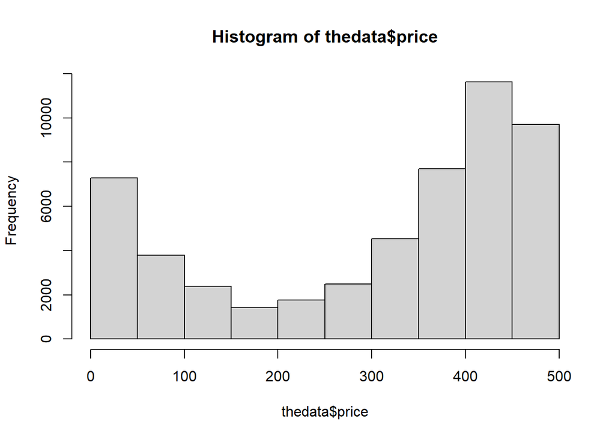

```r
hist(thedata$price)
```

```r
#duprowsremovd = unique(data[,])
#dim(duprowsremovd) #All columns considered

#duprowsremvd = data %>% distinct(host_id,host_name, .keep_all = TRUE)
#dim(duprowsremvd) #unique hostid and hostname considered

#head(duprowsremvd)
```

Now that we have only what we need, We proceed to finding relationship between the data:

#### Relationship between prices and apartment features -

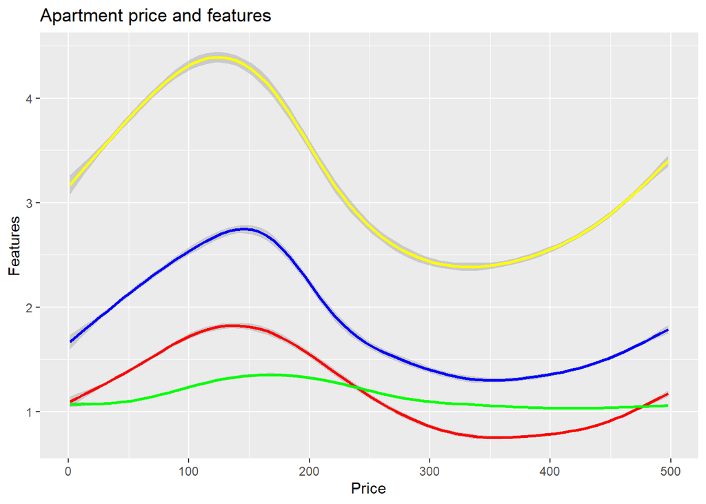

```r
ggplot(data=thedata) +
  geom_smooth(mapping = aes(x=price,y=beds), method = 'gam', col = 'blue') +
  geom_smooth(mapping = aes(x=price,y=bedrooms), method = 'gam', col = 'red') +
  geom_smooth(mapping = aes(x=price,y=bathrooms), method = 'gam', col = 'green') +
  geom_smooth(mapping = aes(x=price,y=accommodates), method = 'gam', col = 'yellow') +
  ggtitle("Apartment price and features") + labs(y= "Features", x = "Price")
```

This graph shows that the apartment features are more in the budget cateogry compared to 300-400 price range but then they tend to rise again as the price of the apartment goes up.

The rise in the number of features in budget category could be justified as most of apartments in this segment are shared(hence more beds,bedrooms etc)

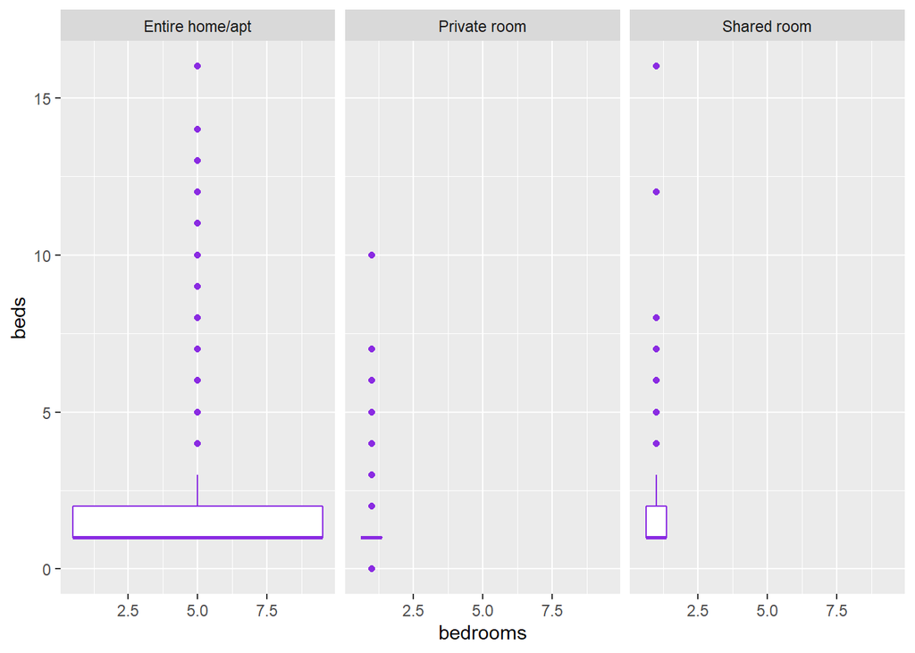

```r
Neighbourhood <- function(string){
  graph = ggplot(data = thedata) + geom_boxplot(aes(y = beds, x = bedrooms),
  col = 'blueviolet') + facet_wrap(~room_type)

  return(graph)
}

Neighbourhood('Paris')
```

#### Price distribution among different room types:

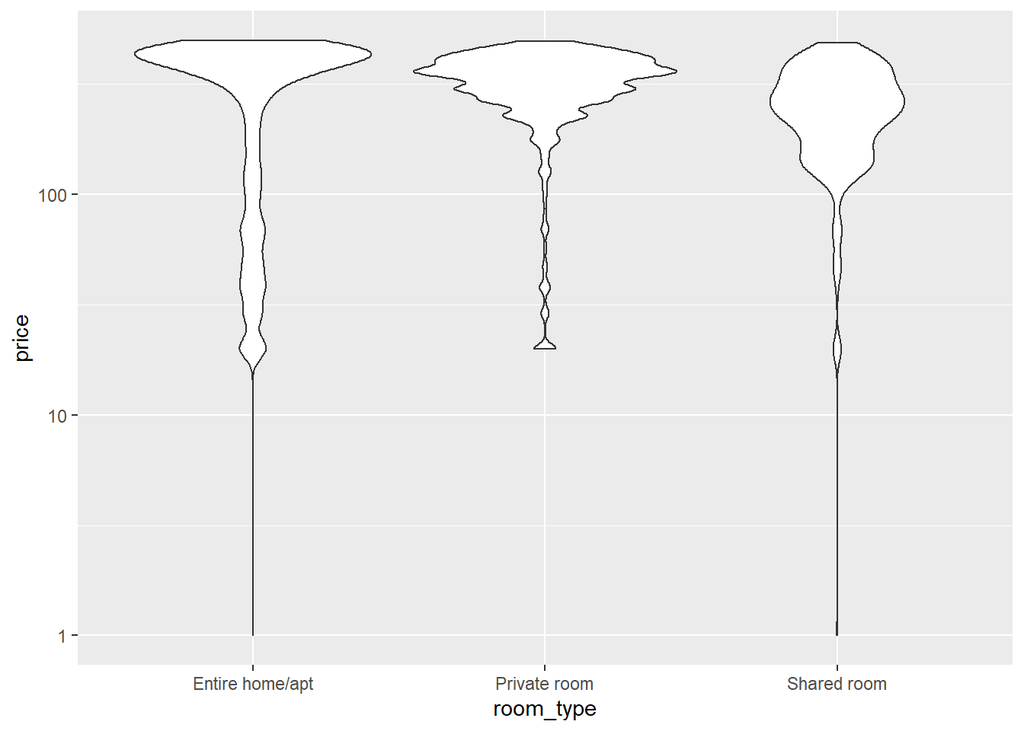

```r
ggplot(thedata, aes(x = room_type, y = price)) +
    geom_violin() +
    scale_y_log10()
```

#### Noticing the trend of amenities around different room types and their prices:

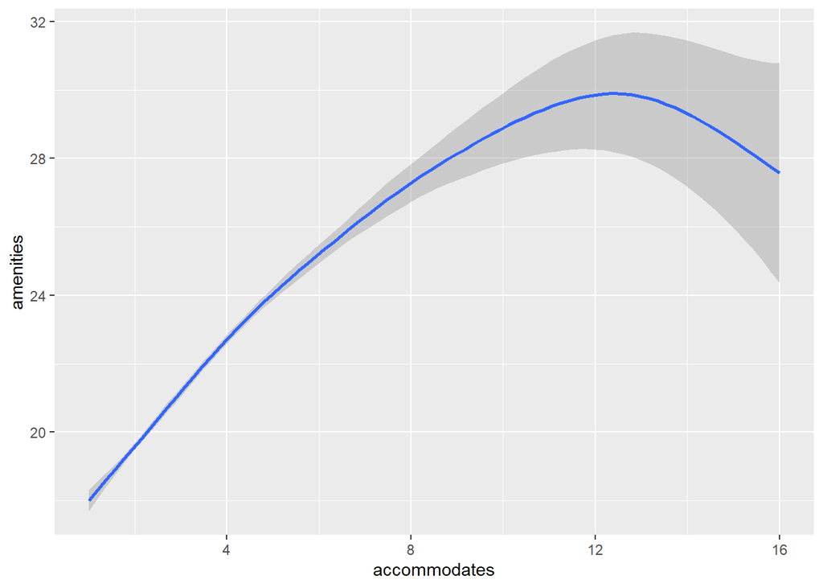

```r
ggplot(data=thedata) + geom_smooth(aes(y=amenities,x=accommodates))
```

This graph illustrates the distribution of amenities for accommodates.

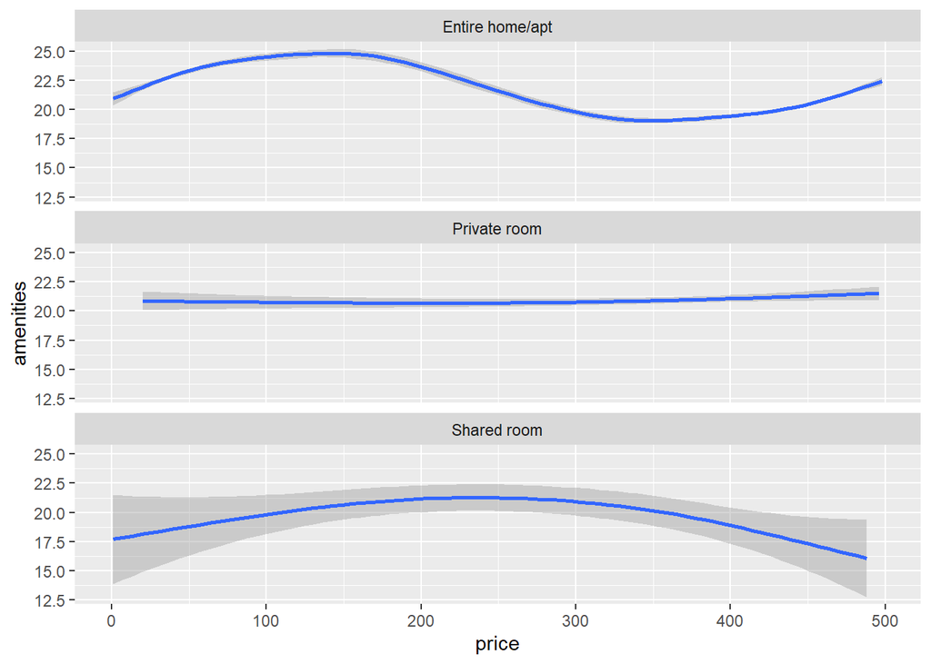

```r
ggplot(data=thedata) + geom_smooth(aes(x=price,y=amenities)) + facet_wrap(~room_type,ncol=1)
```

#### Behaviour of prices across cancellation policies:

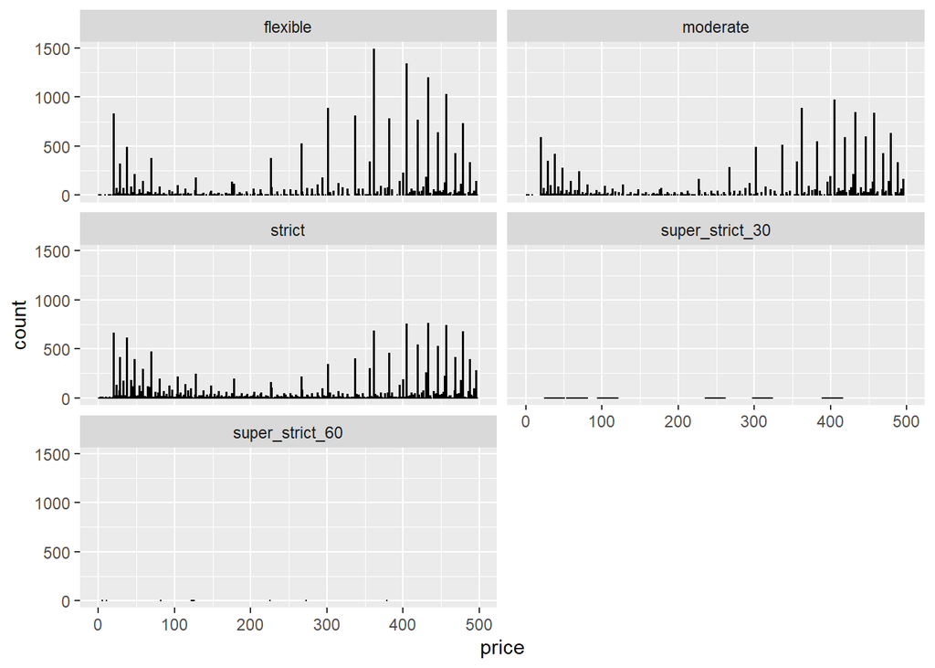

```r
ggplot(data=thedata) + geom_bar(aes(x=price) , col='black') + facet_wrap(~cancellation_policy,ncol=2)
```

We can neatly see the price distributed across cancellation policy (super strict to flexible).

More hosts charging around $350 tend to be flexible with cancellation policies.

#### Here we can see the hosts in contrast to super hosts:

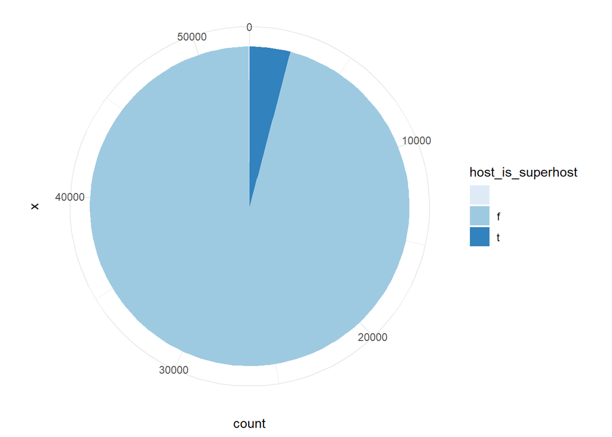

```r
ggplot(L) +
  geom_bar(aes(x='' , fill=host_is_superhost)) +
  coord_polar(theta='y') +
  scale_fill_brewer(palette="Blues")+
  theme_minimal()
```

#### There is an interesting package with in R called:

> ggmap

This allows us draw spatial data on top of static maps from various online sources like Google and Stamen maps, mostly used in geolocation and routing in real time.

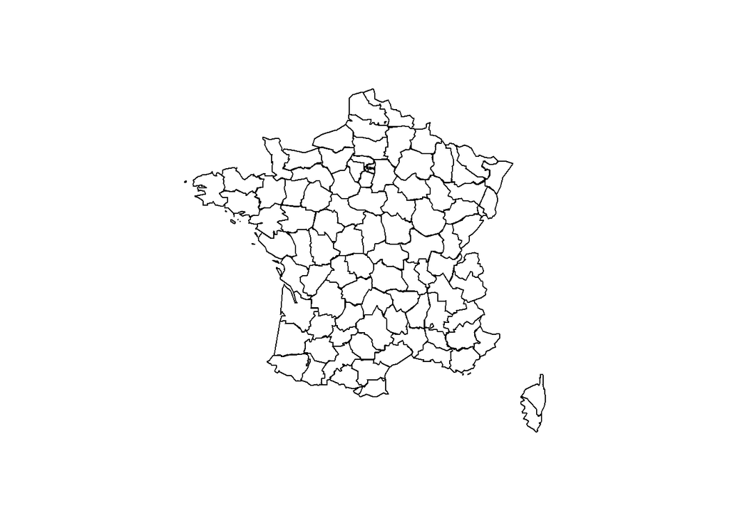

```r
library(maps)
map('france')
```

```r
library(ggmap)

get_map(location = c(lon=46.2276, lat = 2.2137)) #This sets the map location
```

```
## 1280x1280 terrain map image from Google Maps.
## See ?ggmap to plot it.
```

```r
france <- get_map( location = c(lon = 46.2276, lat = 2.2137))
```

```r
#ggmap(france) - We will require a API key to be able to plot this

#Getting the API from google cloud platform :
register_google(key = "AIzaSyDZjd5TEpnt1Rlo_8umbl2g_HJjSad5z1A", write = TRUE)
```

```
## Replacing old key (AIzaSyDZjd5TEpnt1Rlo_8umbl2g_HJjSad5z1A) with new key in C:\Users\verce\Documents/.Renviron
```

[figure not shown]

```r
ggmap(france)
```

##### Since we don’t have a real time requirement for our data we can plot a map using the latitudes and longitudes columns from the data set.

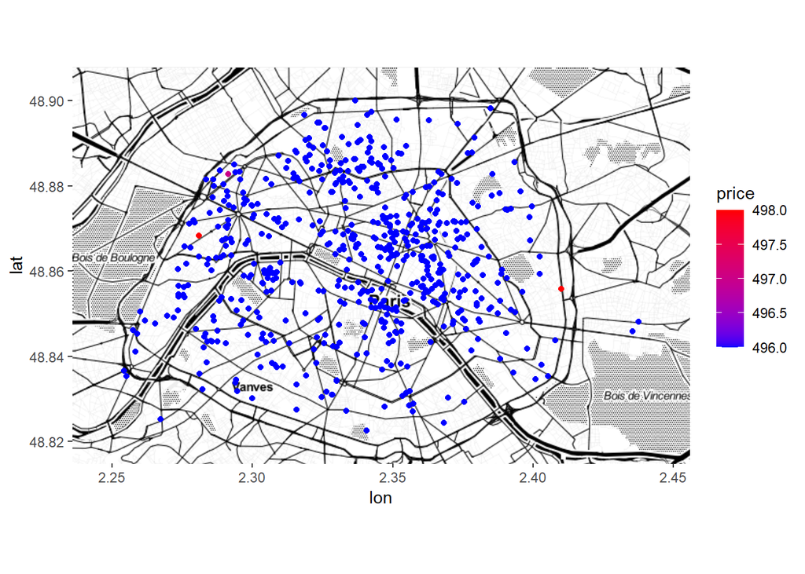

[output not shown]

```r
top_df <- thedata %>% top_n(n = 7, wt = price)

#Setting the map
top_height <- max(top_df$latitude) - min(top_df$latitude)
top_width <- max(top_df$longitude) - min(top_df$longitude)
top_borders <- c(bottom  = min(top_df$latitude)  - 0.1 * top_height,
                 top     = max(top_df$latitude)  + 0.1 * top_height,
                 left    = min(top_df$longitude) - 0.1 * top_width,
                 right   = max(top_df$longitude) + 0.1 * top_width)

  top_map <- get_stamenmap(top_borders, zoom = 12, maptype = "toner")
#Plotting the map

ggmap(top_map) +
    geom_point(data = top_df, mapping = aes(x = longitude, y = latitude,
                                        col = price)) +
    scale_color_gradient(low = "blue", high = "red")
```